# Project 2 Analysis

Juan Hillon

12/13/2020

```r
library(kableExtra)
library(ggplot2)
#loads my_penguins data
load("../Data/my_penguins.rda")
#sources my_rf_cv
source("../Code/my_rf_cv.R")
```

## Tutorial for `my_rf_cv`

This function runs the dataset through a random-forest cross-validation. This function is set up to work with the `my_penguins` dataset. This version of `my_rf_cv` is set up to predict `body_mass_g` using covariates `bill_length_mm`, `bill_depth_mm`, and `flipper_length_mm`. The function returns the cross-validation mean squared error.

To showcase this function, I will run this functions 30 times per each `k`. I will be using `k` values of 2, 5, and 10. I will then create boxplots to display the cross-validation errors, and create a table of the mean cross-validation error for each `k`, along with the standard deviations.

```r
#initialize dataset and remove nas
library(tidyr)
data(my_penguins)
```

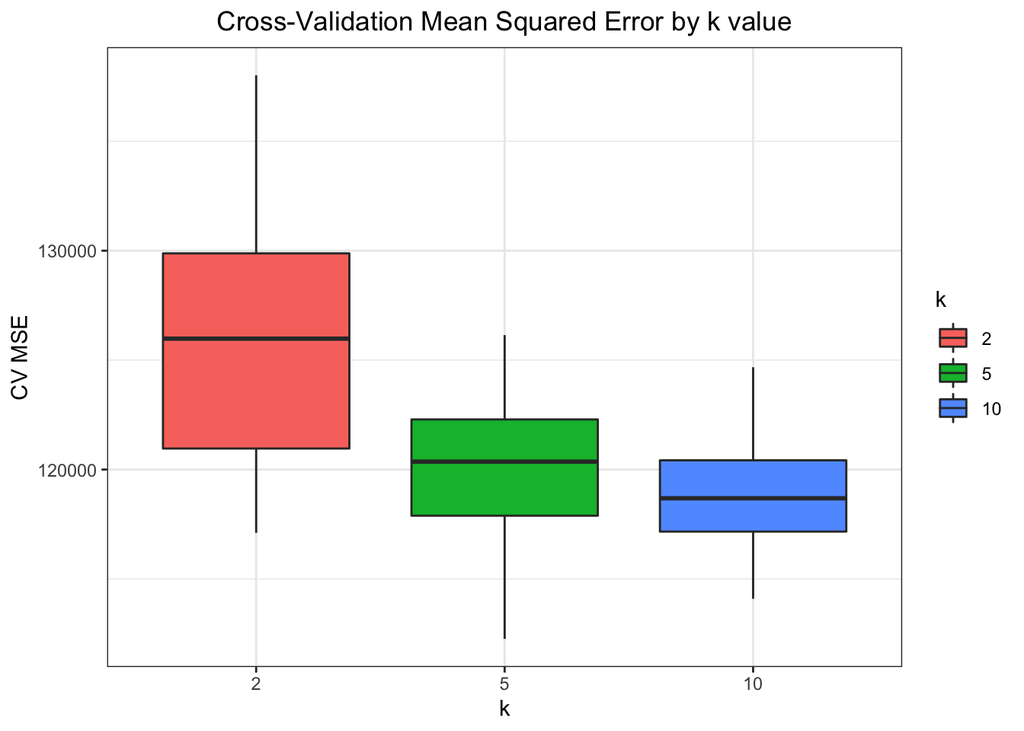

```r
my_data <- drop_na(my_penguins)

#create empty vectors to store cross validation errors
cv_err_2 <- rep(NA, 30)
cv_err_5 <- rep(NA, 30)
cv_err_10 <- rep(NA, 30)

#runs my_rf_cv 30 times per each k value
for (i in 1:30) {
  cv_err_2[i] <- my_rf_cv(2)
  cv_err_5[i] <- my_rf_cv(5)
  cv_err_10[i] <- my_rf_cv(10)
}
#creates datasets out of recorded errors
error_data_2 <- data.frame(k = "2", error = cv_err_2)
error_data_5 <- data.frame(k = "5", error = cv_err_5)
error_data_10 <- data.frame(k = "10", error = cv_err_10)
#for csv
data_for_csv <- data.frame("2" = cv_err_2,
                           "5" = cv_err_5,
                           "10" = cv_err_10)
#for plot
plot_data <- rbind(error_data_2, error_data_5, error_data_10)
#make boxplots
cv_mses <- ggplot(data = plot_data,
                  aes(x = k, y = error, fill = k)) +
                  geom_boxplot() +
                  theme_bw() +
                  labs(title = "Cross-Validation Mean Squared Error by k value",
                  x = "k",
                  y = "CV MSE") +
                  theme(plot.title =
                  element_text(hjust = 0.5))
cv_mses
```

```r
#creates dataset for table
error_stats <- data.frame("Mean CV MSE" =
                            c(mean(cv_err_2), mean(cv_err_5), mean(cv_err_10)),
                          "SD of CV MSE" =
                            c(sd(cv_err_2), sd(cv_err_5), sd(cv_err_10)),
                          row.names = c(2,5,10))
kable_styling(kable(error_stats))
```

|  | Mean.CV.MSE | SD.of.CV.MSE |
| --- | --- | --- |
| 2 | 125841.5 | 5722.893 |
| 5 | 120118.6 | 3223.279 |
| 10 | 118951.3 | 2566.447 |

The boxplots indicate that the cross-validation mean squared errors decrease as `k` increases, with the values varying less as `k` increases. The means and standard deviations confirm this, with both decreasing as `k` increases. Therefore, this indicates that the higher `k` is , `k` being the number of folds, the more accurate the random forest cross-validation is. This makes sense because when there are more folds, `randomForest()` is used to make predictions more. However, the trend shown in the graph and table seems to show diminishing returns for decreasing CV MSE as `k` increases.

```r
#saves plot
ggsave(filename = "../Output/Figures/cv_mse_plot.pdf", plot = cv_mses)
#saves table
saveRDS(error_stats, file = "../Output/Results/summary_stats.rds")
#writes csv of simulation results
write.csv(data_for_csv, file = "../Output/Results/simulated_results.csv")
```